# Introduction to tidyverse/R

Brandon LeBeau

January 8, 2019

# Workshop Logistics

## About Me

- I’m an Assistant Professor in the College of Education
  - I enjoy model building, particularly longitudinal models, and statistical programming.
- I’ve used R for over 10 years.
  - I have 4 R packages, 3 on CRAN, 1 on GitHub, a few more in development.
    - simglm
    - pdfsearch
    - highlightHTML
    - SPSStoR
- GitHub Repository for this workshop: https://github.com/lebebr01/iowa_data_science

## Why teach the tidyverse

- The tidyverse is a series of packages developed by Hadley Wickham and his team at RStudio. https://www.tidyverse.org/
- I teach/use the tidyverse for 3 major reasons:
  - Simple functions that do one thing well
  - Consistent implementations across functions within tidyverse (i.e. common APIs)
  - Provides a framework for data manipulation

## PSQF 6250

- Small plug for my online course
- https://myui.uiowa.edu/my-ui/courses/details.page?id=875209&ci=148839

# Introduction to Tidyverse – Graphics

## Course Setup

```r
install.packages("tidyverse")
```

```r
library(tidyverse)
```

## Explore Data

|  | PID | county | state | area | poptotal | popdensity | popwhite | popblack | popamerindian | popasian | popother | percwhite | percblack | percamerindan | percasian | percother | popadults | perchsd | percollege | percprof | poppovertyknown | percpovertyknown | percbelowpoverty | percchildbelowpovert | percadultpoverty | percelderlypoverty | inmetro | category |
| --- | --- | --- | --- | --- | --- | --- | --- | --- | --- | --- | --- | --- | --- | --- | --- | --- | --- | --- | --- | --- | --- | --- | --- | --- | --- | --- | --- | --- |
| 1 | 561 | ADAMS | IL | 0.052 | 66090 | 1270.96154 | 63917 | 1702 | 98 | 249 | 124 | 96.7120593 | 2.57527614 | 0.14828264 | 0.37675897 | 0.18762294 | 43298 | 75.1073953 | 19.6313918 | 4.35585939 | 63628 | 96.2747768 | 13.1514428 | 18.0117169 | 11.0097759 | 12.4438118 | 0 | AAR |
| 2 | 562 | ALEXANDER | IL | 0.014 | 10626 | 759 | 7054 | 3496 | 19 | 48 | 9 | 66.3843403 | 32.9004329 | 0.1788067 | 0.45172219 | 0.08469791 | 6724 | 59.7263534 | 11.2433076 | 2.87031529 | 10529 | 99.0871447 | 32.2442777 | 45.8265139 | 27.3856467 | 25.2289759 | 0 | LHR |
| 3 | 563 | BOND | IL | 0.022 | 14991 | 681.409091 | 14477 | 429 | 35 | 16 | 34 | 96.5712761 | 2.86171703 | 0.23347342 | 0.10673071 | 0.22680275 | 9669 | 69.3349881 | 17.0338194 | 4.48857172 | 14235 | 94.9569742 | 12.0688444 | 14.036061 | 10.85209 | 12.69741 | 0 | AAR |
| 4 | 564 | BOONE | IL | 0.017 | 30806 | 1812.11765 | 29344 | 127 | 46 | 150 | 1139 | 95.2541713 | 0.41225735 | 0.14932156 | 0.48691813 | 3.69733169 | 19272 | 75.4721876 | 17.2789539 | 4.19779992 | 30337 | 98.4775693 | 7.20901869 | 11.1795358 | 5.53601292 | 6.21704745 | 1 | ALU |
| 5 | 565 | BROWN | IL | 0.018 | 5836 | 324.222222 | 5264 | 547 | 14 | 5 | 6 | 90.1987663 | 9.37285812 | 0.23989034 | 0.08567512 | 0.10281014 | 3979 | 68.861523 | 14.475999 | 3.36768032 | 4815 | 82.5051405 | 13.5202492 | 13.0228887 | 11.1432109 | 19.2 | 0 | AAR |
| 6 | 566 | BUREAU | IL | 0.05 | 35688 | 713.76 | 35157 | 50 | 65 | 195 | 221 | 98.5121049 | 0.14010312 | 0.18213405 | 0.54640215 | 0.61925577 | 23444 | 76.6294148 | 18.9046238 | 3.27589149 | 35107 | 98.3720018 | 10.3996354 | 14.1588185 | 8.17928731 | 11.0085864 | 0 | AAR |
| 7 | 567 | CALHOUN | IL | 0.017 | 5322 | 313.058824 | 5298 | 1 | 8 | 15 | 0 | 99.5490417 | 0.01878993 | 0.15031943 | 0.28184893 | 0 | 3583 | 62.8244488 | 11.9173877 | 3.20960089 | 5241 | 98.4780158 | 15.1497806 | 13.7877614 | 12.9323308 | 21.0852713 | 0 | LAR |
| 8 | 568 | CARROLL | IL | 0.027 | 16805 | 622.407407 | 16519 | 111 | 30 | 61 | 84 | 98.2981256 | 0.6605177 | 0.1785183 | 0.36298721 | 0.49985123 | 11323 | 75.9516029 | 16.1971209 | 3.05572728 | 16455 | 97.9172865 | 11.7107262 | 17.2254616 | 10.0270366 | 9.52505219 | 0 | AAR |
| 9 | 569 | CASS | IL | 0.024 | 13437 | 559.875 | 13384 | 16 | 8 | 23 | 6 | 99.6055667 | 0.1190742 | 0.0595371 | 0.17116916 | 0.04465282 | 8825 | 72.2719547 | 14.1076487 | 3.20679887 | 13081 | 97.3505991 | 13.875086 | 17.9947841 | 11.9143432 | 13.6601796 | 0 | AAR |
| 10 | 570 | CHAMPAIGN | IL | 0.058 | 173025 | 2983.18966 | 146506 | 16559 | 331 | 8033 | 1596 | 84.6733131 | 9.57029331 | 0.19130183 | 4.64268169 | 0.92241006 | 95971 | 87.4993488 | 41.2958081 | 17.7574476 | 154934 | 89.5442855 | 15.5724373 | 14.1322336 | 17.5627276 | 8.1050169 | 1 | HAU |

[output cut: 427 more lines]

## First ggplot

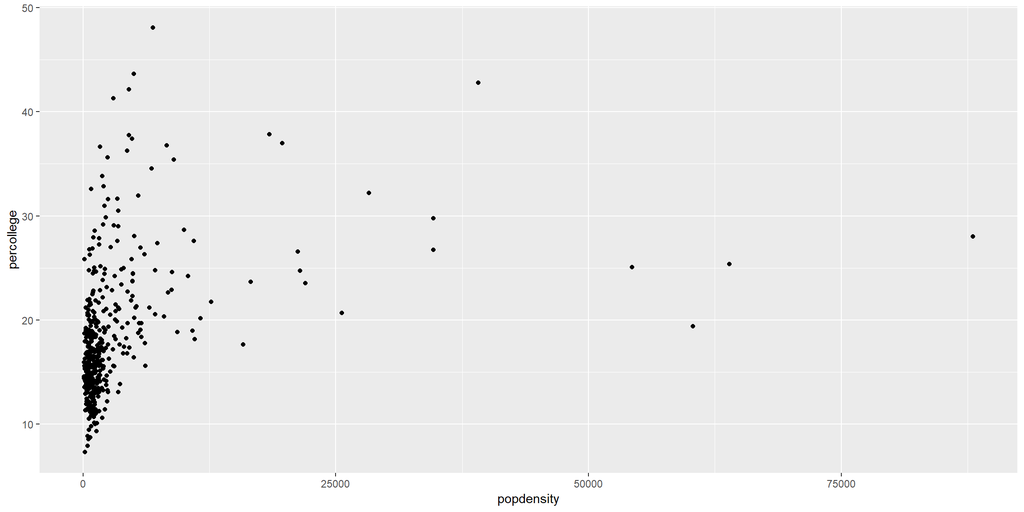

```r
ggplot(data = midwest) +
  geom_point(mapping = aes(x = popdensity, y = percollege))
```

## Equivalent Code

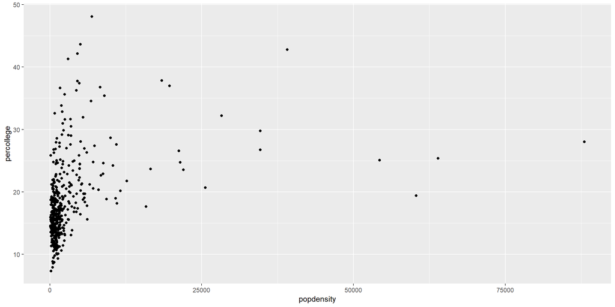

```r
ggplot(midwest) +
  geom_point(aes(x = popdensity, y = percollege))
```

## Your Turn

1. Try plotting `popdensity` by `state`.
2. Try plotting `county` by `state`.
   - Does this plot work?
3. Bonus: Try just using the `ggplot(data = midwest)` from above.
   - What do you get?
   - Does this make sense?

## Add Aesthetics

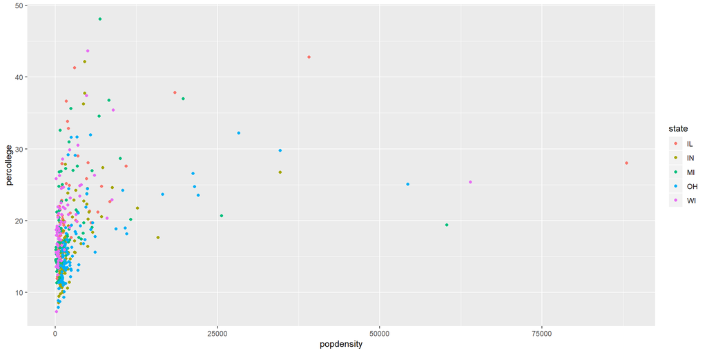

```r
ggplot(midwest) +
  geom_point(aes(x = popdensity, y = percollege, color = state))
```

## Global Aesthetics

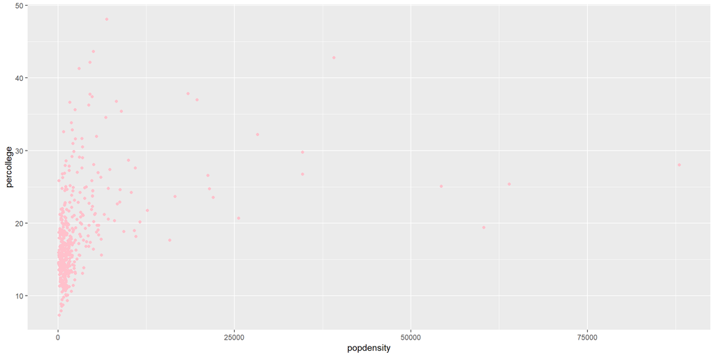

```r
ggplot(midwest) +
  geom_point(aes(x = popdensity, y = percollege), color = 'pink')
```

## Your Turn

1. Instead of using colors, make the shape of the points different for each state.
2. Instead of color, use `alpha` instead.
   - What does this do to the plot?
3. Try the following command: `colors()`.
   - Try a few colors to find your favorite.
4. What happens if you use the following code:

```r
ggplot(midwest) +
  geom_point(aes(x = popdensity, y = percollege, color = 'green'))
```

## Additional Geoms

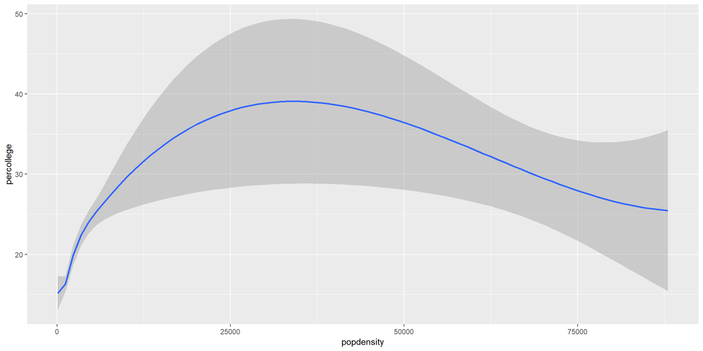

```r
ggplot(midwest) +
  geom_smooth(aes(x = popdensity, y = percollege))
```

## Add more Aesthetics

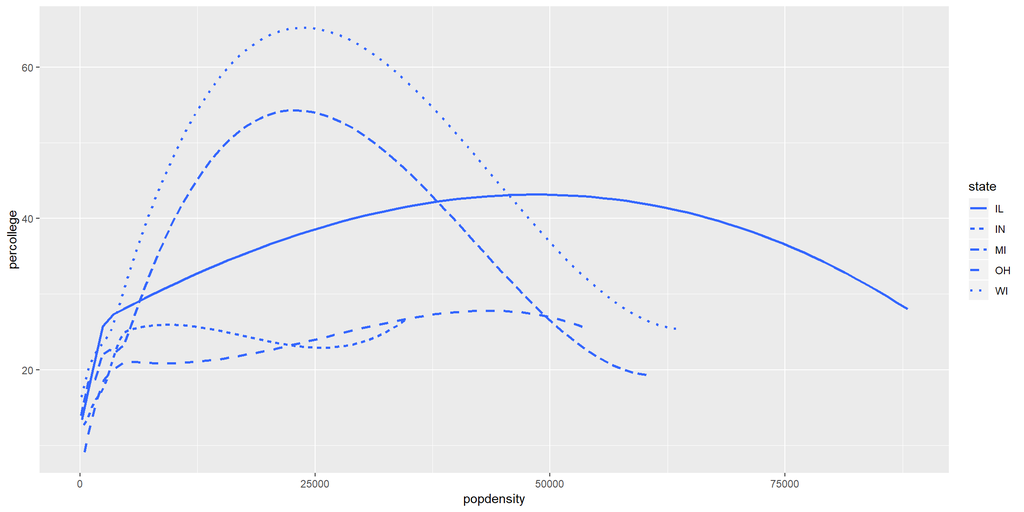

```r
ggplot(midwest) +
  geom_smooth(aes(x = popdensity, y = percollege, linetype = state),
              se = FALSE)
```

## Layered ggplot

```r
ggplot(midwest) +
  geom_point(aes(x = popdensity, y = percollege, color = state)) +
  geom_smooth(aes(x = popdensity, y = percollege, color = state),
              se = FALSE)
```

## Remove duplicate aesthetics

```r
ggplot(midwest,
       aes(x = popdensity, y = percollege, color = state)) +
  geom_point() +
  geom_smooth(se = FALSE)
```

## Your Turn

1. Can you recreate the following figure?

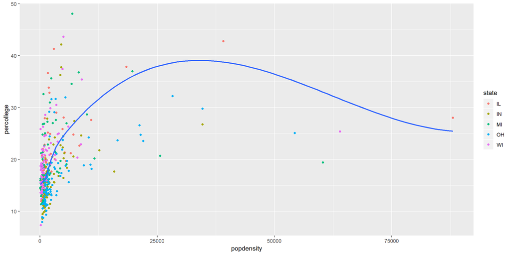

## Brief plot customization

```r
ggplot(midwest,
       aes(x = popdensity, y = percollege, color = state)) +
  geom_point() +
  scale_x_continuous("Population Density",
                     breaks = seq(0, 80000, 20000)) +
  scale_y_continuous("Percent College Graduates") +
  scale_color_discrete("State")
```

## Brief plot customization Output

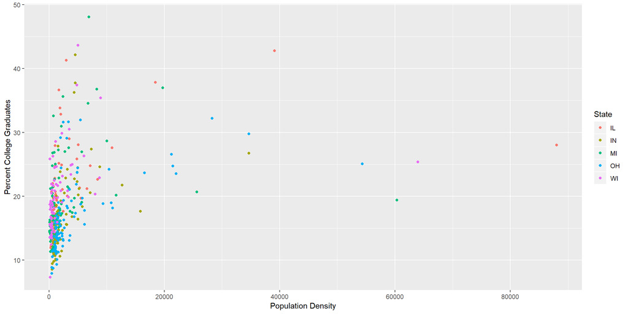

## Add in plot title and subtitle

```r
ggplot(midwest,
       aes(x = popdensity, y = percollege, color = state)) +
  geom_point() +
  scale_x_continuous("Population Density",
                     breaks = seq(0, 80000, 20000)) +
  scale_y_continuous("Percent College Graduates") +
  scale_color_discrete("State") +
  labs(title = "Percent College Educated by Population Density",
       subtitle = "County level data for five midwest states")
```

## Add in plot title and subtitle Output

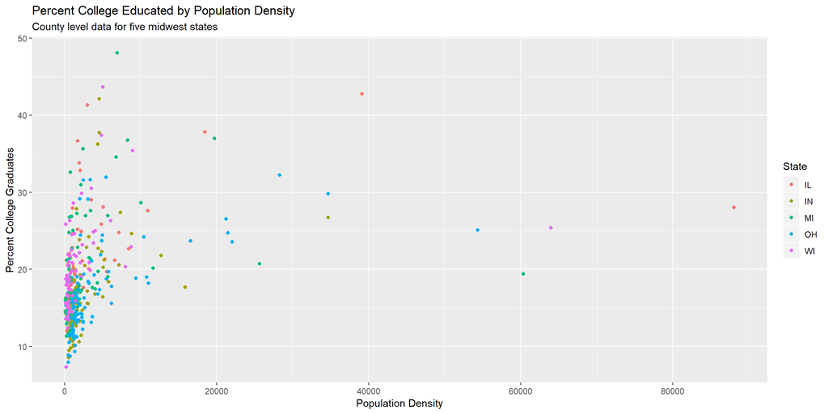

## Additional ggplot2 resources

- ggplot2 website: http://docs.ggplot2.org/current/index.html
- ggplot2 book: http://www.springer.com/us/book/9780387981413
- R graphics cookbook: http://www.cookbook-r.com/Graphs/

# R Basics

## R works as a calculator

```r
1 + 2 - 3
```

```
## [1] 0
```

```r
5 * 7
```

```
## [1] 35
```

```r
2/1
```

```
## [1] 2
```

## R Calculator 2

```r
sqrt(4)
```

```
## [1] 2
```

```r
2^2
```

```
## [1] 4
```

## Can save objects to use later

```r
x <- 1 + 3
x
```

```
## [1] 4
```

```r
x * 3
```

```
## [1] 12
```

## R is case sensitive

```r
case_sensitive <- 10
Case_sensitive
```

```
## Error in eval(expr, envir, enclos): object 'Case_sensitive' not found
```

## R Functions

```r
set.seed(1)
rnorm(n = 5, mean = 0, sd = 1)
```

```
## [1] -0.6264538  0.1836433 -0.8356286  1.5952808  0.3295078
```

```r
set.seed(1)
rnorm(5, 0, 1)
```

```
## [1] -0.6264538  0.1836433 -0.8356286  1.5952808  0.3295078
```

```r
set.seed(1)
rnorm(sd = 1, n = 5, mean = 0)
```

```
## [1] -0.6264538  0.1836433 -0.8356286  1.5952808  0.3295078
```

## Working through Errors

1. Use `?function_name` to explore the details of the function. The examples at the bottom of every R help page can be especially helpful.
   - https://www.rdocumentation.org/ provided by DataCamp is a great alternative as well.
2. If this does not help, copy and paste the error and search on the internet.

# Using `dplyr` for data manipulation

## `dplyr` basics

The `dplyr` package uses verbs for common data manipulation tasks. These include:

- `filter()`
- `count()`
- `arrange()`
- `select()`
- `mutate()`
- `summarise()`

## Data

https://fivethirtyeight.com/features/both-republicans-and-democrats-have-an-age-problem/

```r
install.packages('fivethirtyeight')
library(fivethirtyeight)
```

|  | congress | chamber | bioguide | firstname | middlename | lastname | suffix | birthday | state | party | incumbent | termstart | age |
| --- | --- | --- | --- | --- | --- | --- | --- | --- | --- | --- | --- | --- | --- |
| 1 | 80 | house | M000112 | Joseph | Jefferson | Mansfield |  | 1861-02-09 | TX | D | True | 1947-01-03 | 85.9 |
| 2 | 80 | house | D000448 | Robert | Lee | Doughton |  | 1863-11-07 | NC | D | True | 1947-01-03 | 83.2 |
| 3 | 80 | house | S000001 | Adolph | Joachim | Sabath |  | 1866-04-04 | IL | D | True | 1947-01-03 | 80.7 |
| 4 | 80 | house | E000023 | Charles | Aubrey | Eaton |  | 1868-03-29 | NJ | R | True | 1947-01-03 | 78.8 |
| 5 | 80 | house | L000296 | William |  | Lewis |  | 1868-09-22 | KY | R | False | 1947-01-03 | 78.3 |
| 6 | 80 | house | G000017 | James | A. | Gallagher |  | 1869-01-16 | PA | R | False | 1947-01-03 | 78 |
| 7 | 80 | house | W000265 | Richard | Joseph | Welch |  | 1869-02-13 | CA | R | True | 1947-01-03 | 77.9 |
| 8 | 80 | house | B000565 | Sol |  | Bloom |  | 1870-03-09 | NY | D | True | 1947-01-03 | 76.8 |
| 9 | 80 | house | H000943 | Merlin |  | Hull |  | 1870-12-18 | WI | R | True | 1947-01-03 | 76 |
| 10 | 80 | house | G000169 | Charles | Laceille | Gifford |  | 1871-03-15 | MA | R | True | 1947-01-03 | 75.8 |

[output cut: 90 more lines]

## Using `filter`

```r
filter(congress_age, congress == 80)
```

```
## # A tibble: 555 x 13
##    congress chamber bioguide firstname middlename lastname suffix
##       <int> <chr>   <chr>    <chr>     <chr>      <chr>    <chr>
##  1       80 house   M000112  Joseph    Jefferson  Mansfie~ <NA>
##  2       80 house   D000448  Robert    Lee        Doughton <NA>
##  3       80 house   S000001  Adolph    Joachim    Sabath   <NA>
##  4       80 house   E000023  Charles   Aubrey     Eaton    <NA>
##  5       80 house   L000296  William   <NA>       Lewis    <NA>
##  6       80 house   G000017  James     A.         Gallagh~ <NA>
##  7       80 house   W000265  Richard   Joseph     Welch    <NA>
##  8       80 house   B000565  Sol       <NA>       Bloom    <NA>
##  9       80 house   H000943  Merlin    <NA>       Hull     <NA>
## 10       80 house   G000169  Charles   Laceille   Gifford  <NA>
## # ... with 545 more rows, and 6 more variables: birthday <date>,
## #   state <chr>, party <chr>, incumbent <lgl>, termstart <date>, age <dbl>
```

## Save filtered results to object

```r
congress_80 <- filter(congress_age, congress == 80)
```

## Other operators for numbers

- `>`
- `<`
- `>=`
- `<=`

## Your Turn

1. Select all rows where the congress member was older than 80 at the start of the term.
2. Use the `is.na` function to identify congress members that have missing middlenames.

## Filter character variables

```r
senate <- filter(congress_age, chamber == 'senate')
```

## Combine Operations - AND

```r
filter(congress_age, congress == 80, chamber == 'senate')
```

```
## # A tibble: 102 x 13
##    congress chamber bioguide firstname middlename lastname suffix
##       <int> <chr>   <chr>    <chr>     <chr>      <chr>    <chr>
##  1       80 senate  C000133  Arthur    <NA>       Capper   <NA>
##  2       80 senate  G000418  Theodore  Francis    Green    <NA>
##  3       80 senate  M000499  Kenneth   Douglas    McKellar <NA>
##  4       80 senate  R000112  Clyde     Martin     Reed     <NA>
##  5       80 senate  M000895  Edward    Hall       Moore    <NA>
##  6       80 senate  O000146  John      Holmes     Overton  <NA>
##  7       80 senate  M001108  James     Edward     Murray   <NA>
##  8       80 senate  M000308  Patrick   Anthony    McCarran <NA>
##  9       80 senate  T000165  Elmer     <NA>       Thomas   <NA>
## 10       80 senate  W000021  Robert    Ferdinand  Wagner   <NA>
## # ... with 92 more rows, and 6 more variables: birthday <date>,
## #   state <chr>, party <chr>, incumbent <lgl>, termstart <date>, age <dbl>
```

## Equivalent AND Statement

```r
filter(congress_age, congress == 80 & chamber == 'senate')
```

```
## # A tibble: 102 x 13
##    congress chamber bioguide firstname middlename lastname suffix
##       <int> <chr>   <chr>    <chr>     <chr>      <chr>    <chr>
##  1       80 senate  C000133  Arthur    <NA>       Capper   <NA>
##  2       80 senate  G000418  Theodore  Francis    Green    <NA>
##  3       80 senate  M000499  Kenneth   Douglas    McKellar <NA>
##  4       80 senate  R000112  Clyde     Martin     Reed     <NA>
##  5       80 senate  M000895  Edward    Hall       Moore    <NA>
##  6       80 senate  O000146  John      Holmes     Overton  <NA>
##  7       80 senate  M001108  James     Edward     Murray   <NA>
##  8       80 senate  M000308  Patrick   Anthony    McCarran <NA>
##  9       80 senate  T000165  Elmer     <NA>       Thomas   <NA>
## 10       80 senate  W000021  Robert    Ferdinand  Wagner   <NA>
## # ... with 92 more rows, and 6 more variables: birthday <date>,
## #   state <chr>, party <chr>, incumbent <lgl>, termstart <date>, age <dbl>
```

## Filter - OR

```r
filter(congress_age, congress == 80 | congress == 81)
```

```
## # A tibble: 1,112 x 13
##    congress chamber bioguide firstname middlename lastname suffix
##       <int> <chr>   <chr>    <chr>     <chr>      <chr>    <chr>
##  1       80 house   M000112  Joseph    Jefferson  Mansfie~ <NA>
##  2       80 house   D000448  Robert    Lee        Doughton <NA>
##  3       80 house   S000001  Adolph    Joachim    Sabath   <NA>
##  4       80 house   E000023  Charles   Aubrey     Eaton    <NA>
##  5       80 house   L000296  William   <NA>       Lewis    <NA>
##  6       80 house   G000017  James     A.         Gallagh~ <NA>
##  7       80 house   W000265  Richard   Joseph     Welch    <NA>
##  8       80 house   B000565  Sol       <NA>       Bloom    <NA>
##  9       80 house   H000943  Merlin    <NA>       Hull     <NA>
## 10       80 house   G000169  Charles   Laceille   Gifford  <NA>
## # ... with 1,102 more rows, and 6 more variables: birthday <date>,
## #   state <chr>, party <chr>, incumbent <lgl>, termstart <date>, age <dbl>
```

## `%in%`

```r
filter(congress_age, congress %in% c(80, 81))
```

```
## # A tibble: 1,112 x 13
##    congress chamber bioguide firstname middlename lastname suffix
##       <int> <chr>   <chr>    <chr>     <chr>      <chr>    <chr>
##  1       80 house   M000112  Joseph    Jefferson  Mansfie~ <NA>
##  2       80 house   D000448  Robert    Lee        Doughton <NA>
##  3       80 house   S000001  Adolph    Joachim    Sabath   <NA>
##  4       80 house   E000023  Charles   Aubrey     Eaton    <NA>
##  5       80 house   L000296  William   <NA>       Lewis    <NA>
##  6       80 house   G000017  James     A.         Gallagh~ <NA>
##  7       80 house   W000265  Richard   Joseph     Welch    <NA>
##  8       80 house   B000565  Sol       <NA>       Bloom    <NA>
##  9       80 house   H000943  Merlin    <NA>       Hull     <NA>
## 10       80 house   G000169  Charles   Laceille   Gifford  <NA>
## # ... with 1,102 more rows, and 6 more variables: birthday <date>,
## #   state <chr>, party <chr>, incumbent <lgl>, termstart <date>, age <dbl>
```

## Not Operator

```r
filter(congress_age, congress != 80)
```

```
## # A tibble: 18,080 x 13
##    congress chamber bioguide firstname middlename lastname suffix
##       <int> <chr>   <chr>    <chr>     <chr>      <chr>    <chr>
##  1       81 house   D000448  Robert    Lee        Doughton <NA>
##  2       81 house   S000001  Adolph    Joachim    Sabath   <NA>
##  3       81 house   E000023  Charles   Aubrey     Eaton    <NA>
##  4       81 house   W000265  Richard   Joseph     Welch    <NA>
##  5       81 house   B000565  Sol       <NA>       Bloom    <NA>
##  6       81 house   H000943  Merlin    <NA>       Hull     <NA>
##  7       81 house   B000545  Schuyler  Otis       Bland    <NA>
##  8       81 house   K000138  John      Hosea      Kerr     <NA>
##  9       81 house   C000932  Robert    <NA>       Crosser  <NA>
## 10       81 house   K000039  John      <NA>       Kee      <NA>
## # ... with 18,070 more rows, and 6 more variables: birthday <date>,
## #   state <chr>, party <chr>, incumbent <lgl>, termstart <date>, age <dbl>
```

## Not Operator 2

```r
filter(congress_age, congress == 80 & !chamber == 'senate')
```

```
## # A tibble: 453 x 13
##    congress chamber bioguide firstname middlename lastname suffix
##       <int> <chr>   <chr>    <chr>     <chr>      <chr>    <chr>
##  1       80 house   M000112  Joseph    Jefferson  Mansfie~ <NA>
##  2       80 house   D000448  Robert    Lee        Doughton <NA>
##  3       80 house   S000001  Adolph    Joachim    Sabath   <NA>
##  4       80 house   E000023  Charles   Aubrey     Eaton    <NA>
##  5       80 house   L000296  William   <NA>       Lewis    <NA>
##  6       80 house   G000017  James     A.         Gallagh~ <NA>
##  7       80 house   W000265  Richard   Joseph     Welch    <NA>
##  8       80 house   B000565  Sol       <NA>       Bloom    <NA>
##  9       80 house   H000943  Merlin    <NA>       Hull     <NA>
## 10       80 house   G000169  Charles   Laceille   Gifford  <NA>
## # ... with 443 more rows, and 6 more variables: birthday <date>,
## #   state <chr>, party <chr>, incumbent <lgl>, termstart <date>, age <dbl>
```

## Working with logicals

```r
filter(congress_age, incumbent)
```

```
## # A tibble: 15,698 x 13
##    congress chamber bioguide firstname middlename lastname suffix
##       <int> <chr>   <chr>    <chr>     <chr>      <chr>    <chr>
##  1       80 house   M000112  Joseph    Jefferson  Mansfie~ <NA>
##  2       80 house   D000448  Robert    Lee        Doughton <NA>
##  3       80 house   S000001  Adolph    Joachim    Sabath   <NA>
##  4       80 house   E000023  Charles   Aubrey     Eaton    <NA>
##  5       80 house   W000265  Richard   Joseph     Welch    <NA>
##  6       80 house   B000565  Sol       <NA>       Bloom    <NA>
##  7       80 house   H000943  Merlin    <NA>       Hull     <NA>
##  8       80 house   G000169  Charles   Laceille   Gifford  <NA>
##  9       80 house   B000545  Schuyler  Otis       Bland    <NA>
## 10       80 house   R000358  John      Marshall   Robsion  <NA>
## # ... with 15,688 more rows, and 6 more variables: birthday <date>,
## #   state <chr>, party <chr>, incumbent <lgl>, termstart <date>, age <dbl>
```

## Your Turn

1. Select the Senators from Iowa.
2. Select the Senators from Iowa that are not inbumbents.

## All boolean options

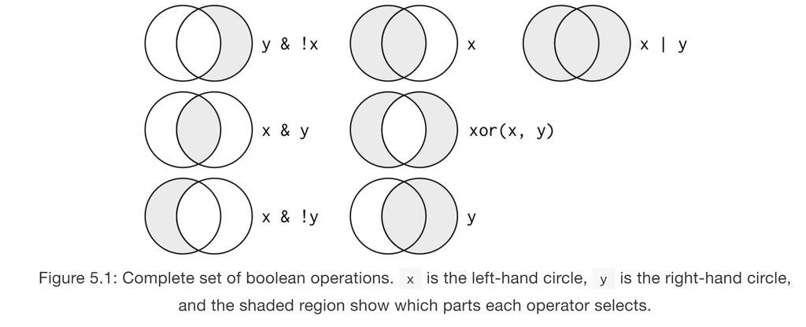

## Using `count`

```r
count(congress_age, party)
```

```
## # A tibble: 6 x 2
##   party     n
##   <chr> <int>
## 1 AL        3
## 2 D     10290
## 3 I        63
## 4 ID        4
## 5 L         1
## 6 R      8274
```

```r
count(congress_age, incumbent)
```

```
## # A tibble: 2 x 2
##   incumbent     n
##   <lgl>     <int>
## 1 FALSE      2937
## 2 TRUE      15698
```

## Using `arrange`

```r
arrange(congress_age, state)
```

```
## # A tibble: 18,635 x 13
##    congress chamber bioguide firstname middlename lastname suffix
##       <int> <chr>   <chr>    <chr>     <chr>      <chr>    <chr>
##  1       80 house   B000201  Edward    Lewis      Bartlett <NA>
##  2       81 house   B000201  Edward    Lewis      Bartlett <NA>
##  3       82 house   B000201  Edward    Lewis      Bartlett <NA>
##  4       83 house   B000201  Edward    Lewis      Bartlett <NA>
##  5       84 house   B000201  Edward    Lewis      Bartlett <NA>
##  6       85 house   B000201  Edward    Lewis      Bartlett <NA>
##  7       86 house   R000282  Ralph     Julian     Rivers   <NA>
##  8       86 senate  G000508  Ernest    <NA>       Gruening <NA>
##  9       86 senate  B000201  Edward    Lewis      Bartlett <NA>
## 10       87 house   R000282  Ralph     Julian     Rivers   <NA>
## # ... with 18,625 more rows, and 6 more variables: birthday <date>,
## #   state <chr>, party <chr>, incumbent <lgl>, termstart <date>, age <dbl>
```

## Add more variables

```r
arrange(congress_age, state, party)
```

```
## # A tibble: 18,635 x 13
##    congress chamber bioguide firstname middlename lastname suffix
##       <int> <chr>   <chr>    <chr>     <chr>      <chr>    <chr>
##  1       80 house   B000201  Edward    Lewis      Bartlett <NA>
##  2       81 house   B000201  Edward    Lewis      Bartlett <NA>
##  3       82 house   B000201  Edward    Lewis      Bartlett <NA>
##  4       83 house   B000201  Edward    Lewis      Bartlett <NA>
##  5       84 house   B000201  Edward    Lewis      Bartlett <NA>
##  6       85 house   B000201  Edward    Lewis      Bartlett <NA>
##  7       86 house   R000282  Ralph     Julian     Rivers   <NA>
##  8       86 senate  G000508  Ernest    <NA>       Gruening <NA>
##  9       86 senate  B000201  Edward    Lewis      Bartlett <NA>
## 10       87 house   R000282  Ralph     Julian     Rivers   <NA>
## # ... with 18,625 more rows, and 6 more variables: birthday <date>,
## #   state <chr>, party <chr>, incumbent <lgl>, termstart <date>, age <dbl>
```

## Descending Order

```r
arrange(congress_age, desc(congress))
```

```
## # A tibble: 18,635 x 13
##    congress chamber bioguide firstname middlename lastname suffix
##       <int> <chr>   <chr>    <chr>     <chr>      <chr>    <chr>
##  1      113 house   H000067  Ralph     M.         Hall     <NA>
##  2      113 house   D000355  John      D.         Dingell  <NA>
##  3      113 house   C000714  John      <NA>       Conyers  Jr.
##  4      113 house   S000480  Louise    McIntosh   Slaught~ <NA>
##  5      113 house   R000053  Charles   B.         Rangel   <NA>
##  6      113 house   J000174  Sam       Robert     Johnson  <NA>
##  7      113 house   Y000031  C.        W. Bill    Young    <NA>
##  8      113 house   C000556  Howard    <NA>       Coble    <NA>
##  9      113 house   L000263  Sander    M.         Levin    <NA>
## 10      113 house   Y000033  Don       E.         Young    <NA>
## # ... with 18,625 more rows, and 6 more variables: birthday <date>,
## #   state <chr>, party <chr>, incumbent <lgl>, termstart <date>, age <dbl>
```

## Your Turn

1. Count the number of congress members from each party that are older than 80 at term start.
2. Arrange the result from above by the variable n.

## Using `select`

```r
select(congress_age, congress, chamber, party, age)
```

```
## # A tibble: 18,635 x 4
##    congress chamber party   age
##       <int> <chr>   <chr> <dbl>
##  1       80 house   D      85.9
##  2       80 house   D      83.2
##  3       80 house   D      80.7
##  4       80 house   R      78.8
##  5       80 house   R      78.3
##  6       80 house   R      78
##  7       80 house   R      77.9
##  8       80 house   D      76.8
##  9       80 house   R      76
## 10       80 house   R      75.8
## # ... with 18,625 more rows
```

## Helper functions

- `starts_with()`
- `ends_with()`
- `contains()`
- `matches()`
- `num_range()`
- `:`
- `everything()`

## `starts_with` helper

```r
select(congress_age, starts_with('s'))
```

```
## # A tibble: 18,635 x 2
##    suffix state
##    <chr>  <chr>
##  1 <NA>   TX
##  2 <NA>   NC
##  3 <NA>   IL
##  4 <NA>   NJ
##  5 <NA>   KY
##  6 <NA>   PA
##  7 <NA>   CA
##  8 <NA>   NY
##  9 <NA>   WI
## 10 <NA>   MA
## # ... with 18,625 more rows
```

## Contains helper

```r
select(congress_age, contains('name'))
```

```
## # A tibble: 18,635 x 3
##    firstname middlename lastname
##    <chr>     <chr>      <chr>
##  1 Joseph    Jefferson  Mansfield
##  2 Robert    Lee        Doughton
##  3 Adolph    Joachim    Sabath
##  4 Charles   Aubrey     Eaton
##  5 William   <NA>       Lewis
##  6 James     A.         Gallagher
##  7 Richard   Joseph     Welch
##  8 Sol       <NA>       Bloom
##  9 Merlin    <NA>       Hull
## 10 Charles   Laceille   Gifford
## # ... with 18,625 more rows
```

## Colon

```r
select(congress_age, congress:birthday)
```

```
## # A tibble: 18,635 x 8
##    congress chamber bioguide firstname middlename lastname suffix
##       <int> <chr>   <chr>    <chr>     <chr>      <chr>    <chr>
##  1       80 house   M000112  Joseph    Jefferson  Mansfie~ <NA>
##  2       80 house   D000448  Robert    Lee        Doughton <NA>
##  3       80 house   S000001  Adolph    Joachim    Sabath   <NA>
##  4       80 house   E000023  Charles   Aubrey     Eaton    <NA>
##  5       80 house   L000296  William   <NA>       Lewis    <NA>
##  6       80 house   G000017  James     A.         Gallagh~ <NA>
##  7       80 house   W000265  Richard   Joseph     Welch    <NA>
##  8       80 house   B000565  Sol       <NA>       Bloom    <NA>
##  9       80 house   H000943  Merlin    <NA>       Hull     <NA>
## 10       80 house   G000169  Charles   Laceille   Gifford  <NA>
## # ... with 18,625 more rows, and 1 more variable: birthday <date>
```

## Drop variables

```r
select(congress_age, -firstname, -state, -party, -incumbent, -chamber)
```

```
## # A tibble: 18,635 x 8
##    congress bioguide middlename lastname suffix birthday   termstart    age
##       <int> <chr>    <chr>      <chr>    <chr>  <date>     <date>     <dbl>
##  1       80 M000112  Jefferson  Mansfie~ <NA>   1861-02-09 1947-01-03  85.9
##  2       80 D000448  Lee        Doughton <NA>   1863-11-07 1947-01-03  83.2
##  3       80 S000001  Joachim    Sabath   <NA>   1866-04-04 1947-01-03  80.7
##  4       80 E000023  Aubrey     Eaton    <NA>   1868-03-29 1947-01-03  78.8
##  5       80 L000296  <NA>       Lewis    <NA>   1868-09-22 1947-01-03  78.3
##  6       80 G000017  A.         Gallagh~ <NA>   1869-01-16 1947-01-03  78
##  7       80 W000265  Joseph     Welch    <NA>   1869-02-13 1947-01-03  77.9
##  8       80 B000565  <NA>       Bloom    <NA>   1870-03-09 1947-01-03  76.8
##  9       80 H000943  <NA>       Hull     <NA>   1870-12-18 1947-01-03  76
## 10       80 G000169  Laceille   Gifford  <NA>   1871-03-15 1947-01-03  75.8
## # ... with 18,625 more rows
```

## Reorder with `everything`

```r
select(congress_age, congress, chamber, incumbent, age, everything())
```

```
## # A tibble: 18,635 x 13
##    congress chamber incumbent   age bioguide firstname middlename lastname
##       <int> <chr>   <lgl>     <dbl> <chr>    <chr>     <chr>      <chr>
##  1       80 house   TRUE       85.9 M000112  Joseph    Jefferson  Mansfie~
##  2       80 house   TRUE       83.2 D000448  Robert    Lee        Doughton
##  3       80 house   TRUE       80.7 S000001  Adolph    Joachim    Sabath
##  4       80 house   TRUE       78.8 E000023  Charles   Aubrey     Eaton
##  5       80 house   FALSE      78.3 L000296  William   <NA>       Lewis
##  6       80 house   FALSE      78   G000017  James     A.         Gallagh~
##  7       80 house   TRUE       77.9 W000265  Richard   Joseph     Welch
##  8       80 house   TRUE       76.8 B000565  Sol       <NA>       Bloom
##  9       80 house   TRUE       76   H000943  Merlin    <NA>       Hull
## 10       80 house   TRUE       75.8 G000169  Charles   Laceille   Gifford
## # ... with 18,625 more rows, and 5 more variables: suffix <chr>,
## #   birthday <date>, state <chr>, party <chr>, termstart <date>
```

## `rename` function

```r
rename(congress_age, first_name = firstname, last_name = lastname)
```

```
## # A tibble: 18,635 x 13
##    congress chamber bioguide first_name middlename last_name suffix
##       <int> <chr>   <chr>    <chr>      <chr>      <chr>     <chr>
##  1       80 house   M000112  Joseph     Jefferson  Mansfield <NA>
##  2       80 house   D000448  Robert     Lee        Doughton  <NA>
##  3       80 house   S000001  Adolph     Joachim    Sabath    <NA>
##  4       80 house   E000023  Charles    Aubrey     Eaton     <NA>
##  5       80 house   L000296  William    <NA>       Lewis     <NA>
##  6       80 house   G000017  James      A.         Gallagher <NA>
##  7       80 house   W000265  Richard    Joseph     Welch     <NA>
##  8       80 house   B000565  Sol        <NA>       Bloom     <NA>
##  9       80 house   H000943  Merlin     <NA>       Hull      <NA>
## 10       80 house   G000169  Charles    Laceille   Gifford   <NA>
## # ... with 18,625 more rows, and 6 more variables: birthday <date>,
## #   state <chr>, party <chr>, incumbent <lgl>, termstart <date>, age <dbl>
```

## Your Turn

1. Using the `dplyr` helper functions, select all the variables that start with the letter ‘c’.
2. Rename the first three variables in the congress data to ‘x1’, ‘x2’, ‘x3’.
3. After renaming the first three variables, use this new data (ensure you saved the previous step to an object) to select these three variables with the `num_range` function.

## Using `mutate`

```r
congress_red <- select(congress_age, congress, chamber, state, party)

mutate(congress_red,
       democrat = ifelse(party == 'D', 1, 0),
       num_democrat = sum(democrat)
       )
```

```
## # A tibble: 18,635 x 6
##    congress chamber state party democrat num_democrat
##       <int> <chr>   <chr> <chr>    <dbl>        <dbl>
##  1       80 house   TX    D            1        10290
##  2       80 house   NC    D            1        10290
##  3       80 house   IL    D            1        10290
##  4       80 house   NJ    R            0        10290
##  5       80 house   KY    R            0        10290
##  6       80 house   PA    R            0        10290
##  7       80 house   CA    R            0        10290
##  8       80 house   NY    D            1        10290
##  9       80 house   WI    R            0        10290
## 10       80 house   MA    R            0        10290
## # ... with 18,625 more rows
```

## Your Turn

1. Using the `diamonds` data, use `?diamonds` for more information on the data, use the `mutate` function to calculate the price per carat. Hint, this operation would involve standardizing the price variable so that all are comparable at 1 carat.
2. Using `mutate`, calculate the rank of the original price variable and the new price variable calculated above using the `min_rank` function. Are there differences in the ranking of the prices?

## Using `summarise`

```r
congress_2 <- mutate(congress_age,
       democrat = ifelse(party == 'D', 1, 0)
       )

summarise(congress_2,
          num_democrat = sum(democrat)
          )
```

```
## # A tibble: 1 x 1
##   num_democrat
##          <dbl>
## 1        10290
```

## `group_by`

```r
congress_grp <- group_by(congress_2, congress)

summarise(congress_grp,
          num_democrat = sum(democrat),
          total = n(),
          prop_democrat = num_democrat / total
)
```

```
## # A tibble: 34 x 4
##    congress num_democrat total prop_democrat
##       <int>        <dbl> <int>         <dbl>
##  1       80          247   555         0.445
##  2       81          330   557         0.592
##  3       82          292   555         0.526
##  4       83          274   557         0.492
##  5       84          288   544         0.529
##  6       85          295   547         0.539
##  7       86          356   554         0.643
##  8       87          339   559         0.606
##  9       88          332   552         0.601
## 10       89          371   548         0.677
## # ... with 24 more rows
```

## Explore trend

```r
num_dem <- summarise(congress_grp,
                     num_democrat = sum(democrat),
                     total = n(),
                     prop_democrat = num_democrat / total
)
ggplot(num_dem, aes(x = congress, y = prop_democrat)) +
  geom_line()
```

## Explore trend output

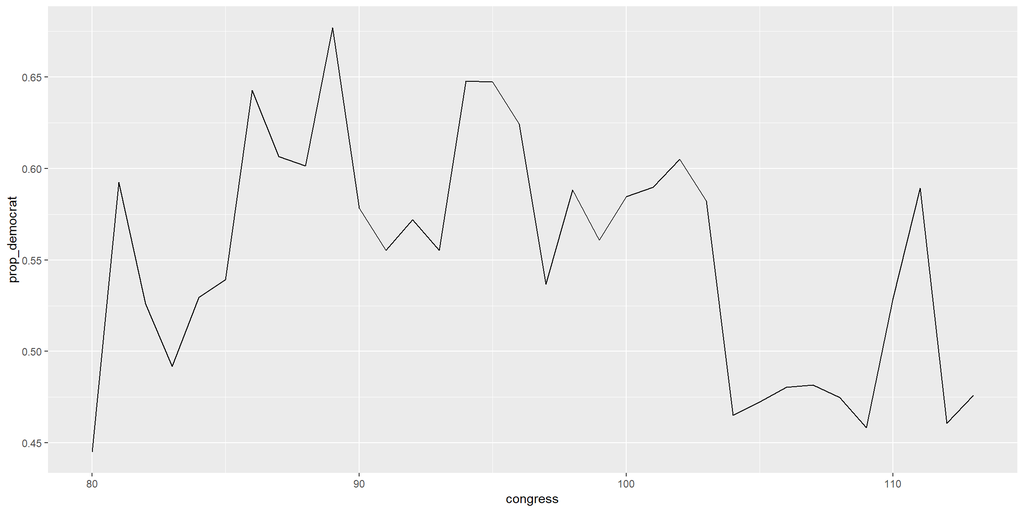

## Your Turn

1. Suppose we wanted to calculate the number and proportion of republicans instead of democrats, assuming these are the only two parties, edit the `summarise` command above to calculate these values.
2. Suppose instead of using `sum(democrat)` above, we used `mean(democrat)`, what does this value return? Why does it return this value?

## `group_by` with `mutate`

```r
congress_red <- select(congress_age, congress, chamber, state, party)
congress_grp <- group_by(congress_red, congress)

mutate(congress_grp,
       democrat = ifelse(party == 'D', 1, 0),
       num_democrat = sum(democrat),
       total = n(),
       prop_democrat = num_democrat / total
)
```

## `group_by` with `mutate` output

```
## # A tibble: 18,635 x 8
## # Groups:   congress [34]
##    congress chamber state party democrat num_democrat total prop_democrat
##       <int> <chr>   <chr> <chr>    <dbl>        <dbl> <int>         <dbl>
##  1       80 house   TX    D            1          247   555         0.445
##  2       80 house   NC    D            1          247   555         0.445
##  3       80 house   IL    D            1          247   555         0.445
##  4       80 house   NJ    R            0          247   555         0.445
##  5       80 house   KY    R            0          247   555         0.445
##  6       80 house   PA    R            0          247   555         0.445
##  7       80 house   CA    R            0          247   555         0.445
##  8       80 house   NY    D            1          247   555         0.445
##  9       80 house   WI    R            0          247   555         0.445
## 10       80 house   MA    R            0          247   555         0.445
## # ... with 18,625 more rows
```

## Chaining operations

```r
summarise(
  group_by(
    mutate(
      filter(
        congress_age, congress >= 100
      ),
      democrat = ifelse(party == 'D', 1, 0)
    ),
    congress, chamber
  ),
  num_democrat = sum(democrat),
  total = n(),
  prop_democrat = num_democrat / total
)
```

## The pipe `%>%` is the answer

```r
congress_age %>%
  filter(congress >= 100) %>%
  mutate(democrat = ifelse(party == 'D', 1, 0)) %>%
  group_by(congress, chamber) %>%
  summarise(
    num_democrat = sum(democrat),
    total = n(),
    prop_democrat = num_democrat / total
  )
```

## The two are identical

```r
pipe_congress <- congress_age %>%
  filter(congress >= 100) %>%
  mutate(democrat = ifelse(party == 'D', 1, 0)) %>%
  group_by(congress, chamber) %>%
  summarise(
    num_democrat = sum(democrat),
    total = n(),
    prop_democrat = num_democrat / total
  )

nested_congress <- summarise(
  group_by(
    mutate(
      filter(
        congress_age, congress >= 100
      ),
      democrat = ifelse(party == 'D', 1, 0)
    ),
    congress, chamber
  ),
  num_democrat = sum(democrat),
  total = n(),
  prop_democrat = num_democrat / total
)

identical(pipe_congress, nested_congress)
```

```
## [1] TRUE
```

## Your Turn

1. Look at the following nested code and determine what is being done. Then translate this code to use the pipe operator.

```r
summarise(
  group_by(
    mutate(
      filter(
        diamonds,
        color %in% c('D', 'E', 'F') & cut %in% c('Fair', 'Good', 'Very Good')
      ),
      f_color = ifelse(color == 'F', 1, 0),
      vg_cut = ifelse(cut == 'Very Good', 1, 0)
    ),
    clarity
  ),
  avg = mean(carat),
  sd = sd(carat),
  avg_p = mean(price),
  num = n(),
  summary_f_color = mean(f_color),
  summary_vg_cut = mean(vg_cut)
)
```

## Other Useful dplyr functions

There are a set of functions that can greatly simplify data operations. These functions end with:

- `*_if`
- `*_each`
- `*_all`
- `*_at`

## Simple example

```r
rename_if(congress_age, is.character, toupper)
```

```
## # A tibble: 18,635 x 13
##    congress CHAMBER BIOGUIDE FIRSTNAME MIDDLENAME LASTNAME SUFFIX
##       <int> <chr>   <chr>    <chr>     <chr>      <chr>    <chr>
##  1       80 house   M000112  Joseph    Jefferson  Mansfie~ <NA>
##  2       80 house   D000448  Robert    Lee        Doughton <NA>
##  3       80 house   S000001  Adolph    Joachim    Sabath   <NA>
##  4       80 house   E000023  Charles   Aubrey     Eaton    <NA>
##  5       80 house   L000296  William   <NA>       Lewis    <NA>
##  6       80 house   G000017  James     A.         Gallagh~ <NA>
##  7       80 house   W000265  Richard   Joseph     Welch    <NA>
##  8       80 house   B000565  Sol       <NA>       Bloom    <NA>
##  9       80 house   H000943  Merlin    <NA>       Hull     <NA>
## 10       80 house   G000169  Charles   Laceille   Gifford  <NA>
## # ... with 18,625 more rows, and 6 more variables: birthday <date>,
## #   STATE <chr>, PARTY <chr>, incumbent <lgl>, termstart <date>, age <dbl>
```

## More realistic example

```r
starwars %>%
  group_by(species, gender) %>%
  summarise_if(is.numeric, mean, na.rm = TRUE)
```

```
## # A tibble: 43 x 5
## # Groups:   species [?]
##    species   gender height  mass birth_year
##    <chr>     <chr>   <dbl> <dbl>      <dbl>
##  1 Aleena    male       79  15        NaN
##  2 Besalisk  male      198 102        NaN
##  3 Cerean    male      198  82         92
##  4 Chagrian  male      196 NaN        NaN
##  5 Clawdite  female    168  55        NaN
##  6 Droid     none      200 140         15
##  7 Droid     <NA>      120  46.3       72.5
##  8 Dug       male      112  40        NaN
##  9 Ewok      male       88  20          8
## 10 Geonosian male      183  80        NaN
## # ... with 33 more rows
```

## Can call more than one function

```r
starwars %>%
  group_by(species, gender) %>%
  summarise_if(is.numeric, funs(mean, median), na.rm = TRUE) %>%
  add_tally()
```

```
## # A tibble: 43 x 9
## # Groups:   species [38]
##    species gender height_mean mass_mean birth_year_mean height_median
##    <chr>   <chr>        <dbl>     <dbl>           <dbl>         <dbl>
##  1 Aleena  male            79      15             NaN              79
##  2 Besali~ male           198     102             NaN             198
##  3 Cerean  male           198      82              92             198
##  4 Chagri~ male           196     NaN             NaN             196
##  5 Clawdi~ female         168      55             NaN             168
##  6 Droid   none           200     140              15             200
##  7 Droid   <NA>           120      46.3            72.5            97
##  8 Dug     male           112      40             NaN             112
##  9 Ewok    male            88      20               8              88
## 10 Geonos~ male           183      80             NaN             183
## # ... with 33 more rows, and 3 more variables: mass_median <dbl>,
## #   birth_year_median <dbl>, n <int>
```

# Data Import

## Read in your own data

- We will use data posted to GitHub: https://github.com/lebebr01/iowa_data_science/tree/master/data

## Data Import

```r
ufo <- read_csv("https://raw.githubusercontent.com/lebebr01/iowa_data_science/master/data/ufo.csv")
```

## Show Data

```r
ufo
```

```
## # A tibble: 8,031 x 7
##    `Date / Time`  City      State Shape  Duration Summary            Posted
##    <chr>          <chr>     <chr> <chr>  <chr>    <chr>              <chr>
##  1 12/12/14 17:30 North Wa~ PA    Trian~ 5 minut~ I heard an extrem~ <NA>
##  2 12/12/14 12:40 Cartersv~ GA    Unkno~ 3.6 min~ Looking up toward~ 12/12~
##  3 12/12/14 06:30 Isle of ~ <NA>  Light  2 secon~ Over the Isle of ~ 12/12~
##  4 12/12/14 01:00 Miamisbu~ OH    Chang~ <NA>     "Bright color cha~ 12/12~
##  5 12/12/14 00:00 Spotsylv~ VA    Unkno~ 1 minute "White then orang~ 12/12~
##  6 12/11/14 23:25 Kenner    LA    Chevr~ ~1 minu~ Strange, chevron-~ 12/12~
##  7 12/11/14 23:15 Eugene    OR    Disk   2 minut~ Dual orange orbs ~ 12/12~
##  8 12/11/14 20:04 Phoenix   AZ    Chevr~ 3 minut~ 4 Orange Lights S~ 12/12~
##  9 12/11/14 20:00 Franklin  NC    Disk   5 minut~ There were 5 or 6~ 12/12~
## 10 12/11/14 18:30 Longview  WA    Cylin~ 10 seco~ Two cylinder shap~ 12/12~
## # ... with 8,021 more rows
```

## Manual column names

```r
ufo_man <- read_csv("https://raw.githubusercontent.com/lebebr01/iowa_data_science/master/data/ufo.csv",
         skip = 1,
         col_names = c('Date/Time', 'City', 'State',
                       'Shape', 'Duration', 'Summary',
                       'Posted'))
```

## Manual column names output

```r
ufo_man
```

```
## # A tibble: 8,031 x 7
##    `Date/Time`  City      State Shape  Duration Summary              Posted
##    <chr>        <chr>     <chr> <chr>  <chr>    <chr>                <chr>
##  1 12/12/14 17~ North Wa~ PA    Trian~ 5 minut~ I heard an extremel~ <NA>
##  2 12/12/14 12~ Cartersv~ GA    Unkno~ 3.6 min~ Looking up towards ~ 12/12~
##  3 12/12/14 06~ Isle of ~ <NA>  Light  2 secon~ Over the Isle of Ma~ 12/12~
##  4 12/12/14 01~ Miamisbu~ OH    Chang~ <NA>     "Bright color chang~ 12/12~
##  5 12/12/14 00~ Spotsylv~ VA    Unkno~ 1 minute "White then orange ~ 12/12~
##  6 12/11/14 23~ Kenner    LA    Chevr~ ~1 minu~ Strange, chevron-sh~ 12/12~
##  7 12/11/14 23~ Eugene    OR    Disk   2 minut~ Dual orange orbs in~ 12/12~
##  8 12/11/14 20~ Phoenix   AZ    Chevr~ 3 minut~ 4 Orange Lights Spo~ 12/12~
##  9 12/11/14 20~ Franklin  NC    Disk   5 minut~ There were 5 or 6 l~ 12/12~
## 10 12/11/14 18~ Longview  WA    Cylin~ 10 seco~ Two cylinder shaped~ 12/12~
## # ... with 8,021 more rows
```

## Manual column types

```r
ufo_date <- read_csv("Data/ufo.csv",
         col_types = list(
           'Date / Time' = col_datetime(format = "%m/%d/%y %H:%M"),
           City = col_character(),
           State = col_character(),
           Shape = col_character(),
           Duration = col_character(),
           Summary = col_character(),
           Posted = col_character()
         ))
```

## Manual column types output

```r
ufo_date
```

```
## # A tibble: 8,031 x 7
##    `Date / Time`       City     State Shape  Duration Summary        Posted
##    <dttm>              <chr>    <chr> <chr>  <chr>    <chr>          <chr>
##  1 2014-12-12 17:30:00 North W~ PA    Trian~ 5 minut~ I heard an ex~ <NA>
##  2 2014-12-12 12:40:00 Carters~ GA    Unkno~ 3.6 min~ Looking up to~ 12/12~
##  3 2014-12-12 06:30:00 Isle of~ <NA>  Light  2 secon~ Over the Isle~ 12/12~
##  4 2014-12-12 01:00:00 Miamisb~ OH    Chang~ <NA>     "Bright color~ 12/12~
##  5 2014-12-12 00:00:00 Spotsyl~ VA    Unkno~ 1 minute "White then o~ 12/12~
##  6 2014-12-11 23:25:00 Kenner   LA    Chevr~ ~1 minu~ Strange, chev~ 12/12~
##  7 2014-12-11 23:15:00 Eugene   OR    Disk   2 minut~ Dual orange o~ 12/12~
##  8 2014-12-11 20:04:00 Phoenix  AZ    Chevr~ 3 minut~ 4 Orange Ligh~ 12/12~
##  9 2014-12-11 20:00:00 Franklin NC    Disk   5 minut~ There were 5 ~ 12/12~
## 10 2014-12-11 18:30:00 Longview WA    Cylin~ 10 seco~ Two cylinder ~ 12/12~
## # ... with 8,021 more rows
```

## Still problems

```r
problems(ufo_date)
```

```
## # A tibble: 56 x 5
##      row col         expected                 actual   file
##    <int> <chr>       <chr>                    <chr>    <chr>
##  1   119 Date / Time date like %m/%d/%y %H:%M 12/1/14  'Data/ufo.csv'
##  2   194 Date / Time date like %m/%d/%y %H:%M 11/27/14 'Data/ufo.csv'
##  3   236 Date / Time date like %m/%d/%y %H:%M 11/24/14 'Data/ufo.csv'
##  4   407 Date / Time date like %m/%d/%y %H:%M 11/15/14 'Data/ufo.csv'
##  5   665 Date / Time date like %m/%d/%y %H:%M 10/31/14 'Data/ufo.csv'
##  6   797 Date / Time date like %m/%d/%y %H:%M 10/25/14 'Data/ufo.csv'
##  7   946 Date / Time date like %m/%d/%y %H:%M 10/19/14 'Data/ufo.csv'
##  8  1081 Date / Time date like %m/%d/%y %H:%M 10/14/14 'Data/ufo.csv'
##  9  1122 Date / Time date like %m/%d/%y %H:%M 10/12/14 'Data/ufo.csv'
## 10  1123 Date / Time date like %m/%d/%y %H:%M 10/12/14 'Data/ufo.csv'
## # ... with 46 more rows
```

## Other text formats

- tsv - tab separated files - `read_tsv`
- fixed width files - `read_fwf`
- white space generally - `read_table`
- delimiter generally - `read_delim`

## Your Turn

1. There is a tsv file posted on icon called “lotr_clean.tsv”. Download this and read this data file into R.
2. Instead of specifying the path, use the function `file.choose()`. For example, `read_tsv(file.choose())`.
   - What does this function do?
   - Would you recommend this to be used in a reproducible document?

## Excel Files

```r
install.packages('readxl')
```

## `read_excel`

```r
library(readxl)
read_excel('data/titanic.xlsx')
```

```
## readxl works best with a newer version of the tibble package.
## You currently have tibble v1.4.2.
## Falling back to column name repair from tibble <= v1.4.2.
## Message displays once per session.
```

```
## # A tibble: 891 x 12
##    PassengerId Survived Pclass Name  Sex     Age SibSp Parch Ticket  Fare
##          <dbl>    <dbl>  <dbl> <chr> <chr> <dbl> <dbl> <dbl> <chr>  <dbl>
##  1           1        0      3 Brau~ male     22     1     0 A/5 2~  7.25
##  2           2        1      1 Cumi~ fema~    38     1     0 PC 17~ 71.3
##  3           3        1      3 Heik~ fema~    26     0     0 STON/~  7.92
##  4           4        1      1 Futr~ fema~    35     1     0 113803 53.1
##  5           5        0      3 Alle~ male     35     0     0 373450  8.05
##  6           6        0      3 Mora~ male     NA     0     0 330877  8.46
##  7           7        0      1 McCa~ male     54     0     0 17463  51.9
##  8           8        0      3 Pals~ male      2     3     1 349909 21.1
##  9           9        1      3 John~ fema~    27     0     2 347742 11.1
## 10          10        1      2 Nass~ fema~    14     1     0 237736 30.1
## # ... with 881 more rows, and 2 more variables: Cabin <chr>,
## #   Embarked <chr>
```

## Write Output Files

```r
ufo_count <- ufo %>%
  group_by(State) %>%
  mutate(num_state = n())

write_csv(ufo_count, path = 'path/to/save/file.csv')
```

## Additional Resources

- R for Data Science: http://r4ds.had.co.nz/